# Overview of Data Sets Included in the Meta-Analysis

MPT Reanalysis Project (code and text current document: Henrik Singmann)

Results from: 2021-06-01

## Models

The results include 9 different models (some of which with additional submodels):

- `2htsm`: 2-high threshold source memory model
- `c2ht`: confidence-rating 2-high threshold memory model
- `pc`: pair-clustering model
- `pd`: process-dissociation
- `pm`: prospective memory model
- `hb`: hindsight-bias model
- `rm`: r-model
- `real`: real model (IAT)
- `quad`: quad model (IAT)

## Participants and Studies

The following table gives an overview of the number of conditions (`n_within_between` is the number of conditions that each provide at least one parameter per model that otherwise would not be unique given the base-model equations, this includes both within-subjects and between-conditions; `n_between` is the number of between-subjects conditions), number of participants (`par`), and number of data sets (`n_study`). The final table shows the overall results.

```
## # A tibble: 9 x 5
##   model   par n_within_between n_between n_study
##   <fct> <int>            <int>     <int>   <int>
## 1 2htsm  2668              144        88      35
## 2 c2ht    850               15        15      15
## 3 pc      551               82        15       9
## 4 pd      679               33        16      10
## 5 pm     1323               36        30      14
## 6 hb      943               26        25       9
## 7 rm     2680               66        66      42
## 8 real    753               21        21       9
## 9 quad   3509               29        29      21
```

```
## # A tibble: 1 x 4
##     par n_within_between n_between n_study
##   <int>            <int>     <int>   <int>
## 1 13956              452       305     164
```

We can also make this table by submodel.

```
## # A tibble: 13 x 5
##    model2     par n_within_between n_between n_study
##    <fct>    <int>            <int>     <int>   <int>
##  1 2htsm_4   1148              104        70      19
##  2 2htsm_5d  1012               33        14      12
##  3 2htsm_6e   508                7         4       4
##  4 c2ht6      459               12        12      12
##  5 c2ht8      391                3         3       3
##  6 pc         551               82        15       9
##  7 pd_s       437               21        13       7
##  8 pd_e       242               12         3       3
##  9 pm        1323               36        30      14
## 10 hb         943               26        25       9
## 11 rm        2680               66        66      42
## 12 real       753               21        21       9
## 13 quad      3509               29        29      21
```

```
## # A tibble: 1 x 4
##     par n_within_between n_between n_study
##   <int>            <int>     <int>   <int>
## 1 13956              452       305     164
```

## Number of Parameter Estimates

We can also get an overview of the number of (core) parameter estimates per model:

```
## # A tibble: 9 x 2
##   model     n
##   <fct> <int>
## 1 2htsm   623
## 2 c2ht     45
## 3 pc      246
## 4 pd       62
## 5 pm      144
## 6 hb      103
## 7 rm      264
## 8 real    147
## 9 quad    145
```

Overall this provides the following number of estimates:

```
## # A tibble: 1 x 1
##       n
##   <int>
## 1  1779
```

If we include all parameters (i.e., core and non-core) we get the following table:

```
## # A tibble: 9 x 2
##   model     n
##   <fct> <int>
## 1 2htsm   623
## 2 c2ht    159
## 3 pc      246
## 4 pd       62
## 5 pm      144
## 6 hb      331
## 7 rm      264
## 8 real    210
## 9 quad    145
```

## Methods

The following table gives the proportion of data sets for which a given method (in columns) produced usable results (i.e., also considering our convergence criteria). This first table is separated by models.

```
## # A tibble: 9 x 11
##   model `Comp MLE` `Comp Bayes` `No asy` `No PB` `No NPB` `No Bayes` `LC PP` `Beta PP` `Trait_u PP` `Trait PP`
##   <fct>      <dbl>        <dbl>    <dbl>   <dbl>    <dbl>      <dbl>   <dbl>     <dbl>        <dbl>      <dbl>
## 1 2htsm          1            1        1       1    1          0.971   0         1            0.943      0.914
## 2 c2ht           1            1        1       1    1          0.8     0         0.933        1          1
## 3 pc             1            1        1       1    1          1       0         1            1          1
## 4 pd             1            1        1       1    1          1       1         1            1          0.9
## 5 pm             1            1        1       1    1          1       0         1            1          0.929
## 6 hb             1            1        1       1    0.667      1       0         0.889        0.444      0.778
## 7 rm             1            1        1       1    1          1       0.952     1            1          1
## 8 real           1            1        1       1    1          0.778   0         1            1          1
## 9 quad           1            1        1       1    1          1       0         1            0.952      0.952
```

One thing that is clear is that the latent class approach (`LC PP`) is missing in the vast majority of cases.

We can also look at this across all models.

```
## # A tibble: 1 x 10
##   `Comp MLE` `Comp Bayes` `No asy` `No PB` `No NPB` `No Bayes` `LC PP` `Beta PP` `Trait_u PP` `Trait PP`
##        <dbl>        <dbl>    <dbl>   <dbl>    <dbl>      <dbl>   <dbl>     <dbl>        <dbl>      <dbl>
## 1          1            1        1       1    0.982      0.963   0.305     0.988        0.951      0.951
```

## Methods per Data Set

The following tables, which are separated by model, provide an overview of whether each method is usable (`TRUE`), misses our convergence criteria (`FALSE`), or is missing (`NA`).

```
## # A tibble: 35 x 12
##    model dataset                      `Comp MLE` `Comp Bayes` `No asy` `No PB` `No NPB` `No Bayes` `LC PP` `Beta PP` `Trait_u PP` `Trait PP`
##    <fct> <chr>                        <lgl>      <lgl>        <lgl>    <lgl>   <lgl>    <lgl>      <lgl>   <lgl>     <lgl>        <lgl>
##  1 2htsm A2013                        TRUE       TRUE         TRUE     TRUE    TRUE     TRUE       NA      TRUE      TRUE         TRUE
##  2 2htsm Bell et al. (2015) Ex1       TRUE       TRUE         TRUE     TRUE    TRUE     TRUE       NA      TRUE      TRUE         TRUE
##  3 2htsm Bell et al. (2015) Ex2       TRUE       TRUE         TRUE     TRUE    TRUE     TRUE       NA      TRUE      TRUE         TRUE
##  4 2htsm Bell et al. (2015) Ex3       TRUE       TRUE         TRUE     TRUE    TRUE     TRUE       NA      TRUE      TRUE         TRUE
##  5 2htsm Bell et al. (2015) Ex4       TRUE       TRUE         TRUE     TRUE    TRUE     TRUE       NA      TRUE      TRUE         TRUE
##  6 2htsm BG2008                       TRUE       TRUE         TRUE     TRUE    TRUE     TRUE       NA      TRUE      FALSE        TRUE
##  7 2htsm BK2011_E1                    TRUE       TRUE         TRUE     TRUE    TRUE     TRUE       NA      TRUE      TRUE         TRUE
##  8 2htsm BK2011_E2                    TRUE       TRUE         TRUE     TRUE    TRUE     TRUE       NA      TRUE      FALSE        TRUE
##  9 2htsm DS2000_E1                    TRUE       TRUE         TRUE     TRUE    TRUE     FALSE      NA      TRUE      TRUE         TRUE
## 10 2htsm DS2000_E3                    TRUE       TRUE         TRUE     TRUE    TRUE     TRUE       NA      TRUE      TRUE         TRUE
## 11 2htsm DS2000_E4                    TRUE       TRUE         TRUE     TRUE    TRUE     TRUE       NA      TRUE      TRUE         FALSE
## 12 2htsm Giang et al. (2012)          TRUE       TRUE         TRUE     TRUE    TRUE     TRUE       NA      TRUE      TRUE         TRUE
```

[output cut: 176 more lines]

## Core Parameters Per Model

The following gives an overview of the core and (if present) non-core parameters for each model.

```
## 2htsm
## Core parameters:
##  b d D g d_1 d_2 D_1 D_2
##
## c2ht
## Core parameters:
##  Dn Do g
## Non-core parameters:
##  q_1 q_2 q_5 q_6 r_1 r_2 r_6 q_3 q_7 q_8 r_3 r_8
##
## pc
## Core parameters:
##  c r u
##
## pd
## Core parameters:
##  A C A_alt C_Inclusion C_Exclusion
##
## pm
## Core parameters:
##  C1 C2 M P
##
## hb
## Core parameters:
##  b c rc re
## Non-core parameters:
##  gg1 gg2 gg3 gl1 gl2 gl3 h2 lc le
##
## rm
## Core parameters:
##  a b g r
##
## real
## Core parameters:
##  A1 A2 L1 L2 L3 L4 Re
## Non-core parameters:
##  attL attReC attReT
##
## quad
## Core parameters:
##  ACbb1 ACwg1 D1 G1 OB1
```

## Core Parameters Per Submodel

The following gives an overview of the core and (if present) non-core parameters for each submodel.

```
## 2htsm_4
## Core parameters:
##  b d D g
##
## 2htsm_5d
## Core parameters:
##  b D d_1 d_2 g
##
## 2htsm_6e
## Core parameters:
##  b d_1 D_1 d_2 D_2 g
##
## c2ht6
## Core parameters:
##  Dn Do g
## Non-core parameters:
##  q_1 q_2 q_5 q_6 r_1 r_2 r_6
##
## c2ht8
## Core parameters:
##  Dn Do g
## Non-core parameters:
##  q_1 q_2 q_3 q_6 q_7 q_8 r_1 r_2 r_3 r_8
##
## pc
## Core parameters:
##  c r u
##
## pd_s
## Core parameters:
##  A C
##
## pd_e
## Core parameters:
##  A_alt C_Inclusion C_Exclusion
##
## pm
## Core parameters:
##  C1 C2 M P
##
## hb
## Core parameters:
##  b c rc re
## Non-core parameters:
##  gg1 gg2 gg3 gl1 gl2 gl3 h2 lc le
##
## rm
## Core parameters:
##  a b g r
##
## real
## Core parameters:
##  A1 A2 L1 L2 L3 L4 Re
## Non-core parameters:
##  attL attReC attReT
##
## quad
## Core parameters:
##  ACbb1 ACwg1 D1 G1 OB1
```

## Pairwise Plots of Core Parameters

We plot the core parameters for each condition that are usable in the following plot.

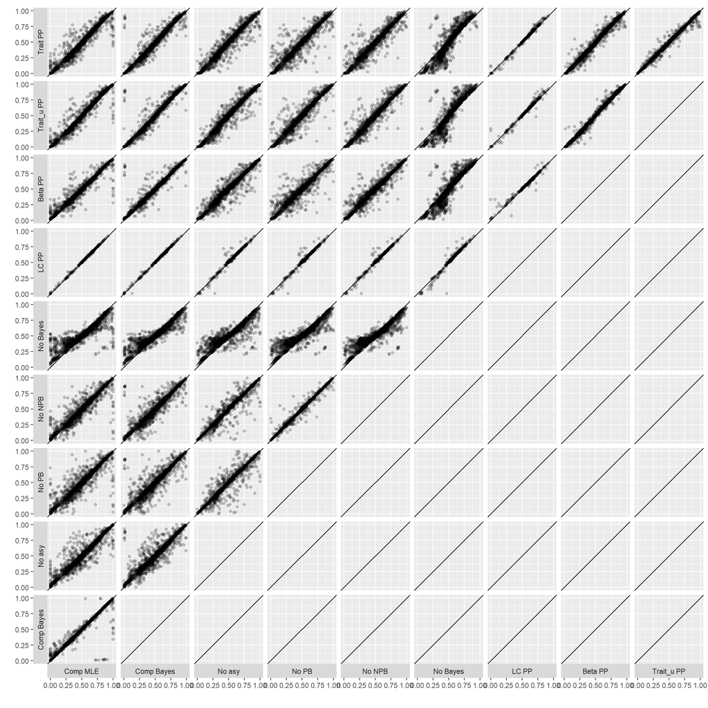

## All Pairwise Plots

We can also plot all pairwise plots (instead of only the upper half of the pairs-matrix) and overlay each plot with a GAM.

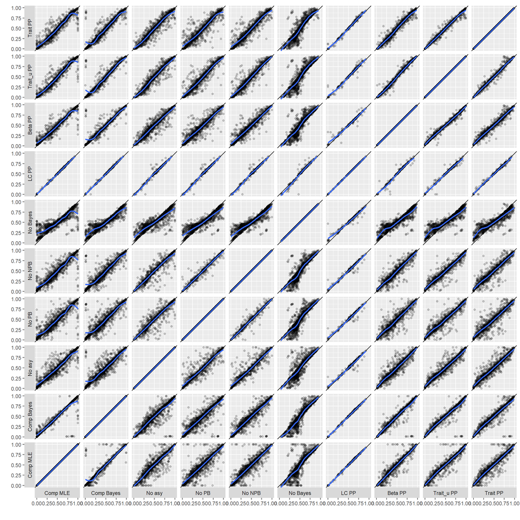